# Main Analysis: Attention to Aversive Attributes (Studies 1 and 2)

## Regressions

Both pooled across studies, with study crossed with every other predictor (Study 1 and Narrow are the reference levels). Net fixation bias: choice on value difference, net dwell time, and range, with subject random slopes on value. Last fixation bias: choosing the last-fixated option on its relative value, the type of the last-fixated box, and range.

```r
if (RUN_REGRESSIONS) {
  d <- pas %>% mutate(Study = factor(Study))

  fit_netfix <- glmmTMB(
    ChooseL ~ Diff10 * DwellDiff * WN * Study + (1 + Diff10 | Subject),
    data = d, family = binomial
  )

  fit_last <- glmmTMB(
    ChooseLast ~ RelDiff10_last * LastType * WN * Study + (1 + RelDiff10_last | Subject),
    data = d %>% filter(!is.na(LastSide)), family = binomial
  )

  # One panel per model.
  tab <- list(
    "Panel A: Choose Left"         = freq_columns(fit_netfix, "Frequentist (glmmTMB)"),
    "Panel B: Choose Last Fixated" = freq_columns(fit_last,   "Frequentist (glmmTMB)")
  )
  note <- sd_note(list("Panel A" = sds_freq(fit_netfix), "Panel B" = sds_freq(fit_last)))
  save_tex(tab, "option_level_attention", note)
}
```

## Text Output

The statistics quoted in the Option-Level Attention paragraphs of the paper.

```r
if (RUN_REGRESSIONS) {
  # Effect of net dwell time to left (log-odds per s) on choosing left,
  # holding value constant, per study. Study 2 adds the DwellDiff:Study2
  # interaction.
  save_text(paste0(
    "$\\beta^{\\text{Dwell}}_{\\text{Study 1}} = ", fmt_coef(fit_netfix, "DwellDiff"), "$, ",
    "$\\beta^{\\text{Dwell}}_{\\text{Study 2}} = ", fmt_coef(fit_netfix, c("DwellDiff", "DwellDiff:Study2")), "$"
  ), "netfix_dwell")
}
```

```r
if (RUN_REGRESSIONS) {
  # Wide minus Narrow difference in the net-dwell effect, per study (Study 2
  # adds the three-way interaction with Study2).
  save_text(paste0(
    "$\\beta^{\\text{Dwell} \\times \\text{Wide}}_{\\text{Study 1}} = ", fmt_coef(fit_netfix, "DwellDiff:WNWide"), "$, ",
    "$\\beta^{\\text{Dwell} \\times \\text{Wide}}_{\\text{Study 2}} = ", fmt_coef(fit_netfix, c("DwellDiff:WNWide", "DwellDiff:WNWide:Study2")), "$"
  ), "netfix_range")
}
```

```r
if (RUN_REGRESSIONS) {
  # Log-odds of choosing the last-fixated option at equal value, for every
  # type x range cell and study (P, Narrow and Study 1 are the reference
  # levels; other cells add the matching main effects and interactions).
  cells <- tibble()
  for (s in 1:2) {
    for (rng in c("Narrow", "Wide")) {
      for (tt in c("P", "N", "B")) {
        terms <- c("(Intercept)",
                   if (tt != "P") paste0("LastType", tt),
                   if (rng == "Wide") "WNWide",
                   if (tt != "P" && rng == "Wide") paste0("LastType", tt, ":WNWide"),
                   if (s == 2) "Study2",
                   if (s == 2 && tt != "P") paste0("LastType", tt, ":Study2"),
                   if (s == 2 && rng == "Wide") "WNWide:Study2",
                   if (s == 2 && tt != "P" && rng == "Wide") paste0("LastType", tt, ":WNWide:Study2"))
        ci <- coef_ci(fit_last, terms)
        cells <- bind_rows(cells, tibble(Study = s, type = tt, WN = rng,
                                         estimate = ci[["estimate"]], lo = ci[["lo"]], hi = ci[["hi"]]))
      }
    }
  }
  cells

  # Report the smallest and largest cell of each study.
  out <- c()
  for (s in 1:2) {
    d <- cells %>% filter(Study == s)
    for (r in list(d[which.min(d$estimate), ], d[which.max(d$estimate), ])) {
      out <- c(out, paste0("$\\beta^{\\text{Last, ", r$type, ", ", r$WN, "}}_{\\text{Study ", s, "}} = ", fmt_ci(r$estimate, r$lo, r$hi), "$"))
    }
  }
  save_text(paste(out, collapse = ", "), "lastfix_bias")
}
```

# Attribute-Level Attention

The central analysis. A **signed attention weight** is the effect of one second of dwell on a box on the log-odds of choosing that box’s option, holding the values of all four boxes constant. One weight per (type x value) cell, with partial pooling: every subject gets their own weight per cell, and we report the population weight. Positive means attention pulls choice toward the attended option; negative means it pushes choice away.

Value is held constant without assuming a linear value function: every (type x value) cell also gets a **utility**, the log-odds contribution of having that value on an option. Its regressor is the cell’s signed presence (+1 if the cell’s box is on the left, -1 on the right, 0 if not on screen). Each attribute type has one box on each side of a trial, so a type’s six presence columns sum to zero on every trial and only differences between the utilities of a type are identified: the lowest value of each type is the reference (utility 0) and the other five are relative to it. A dwell weight is then estimated only from how dwell on a box varies across the trials on which that box is shown. With a linear value function instead (the model in the first version of this notebook, now under Extra Analyses), any gap between a value’s true utility and the line landed on that cell’s dwell weight, because dwell on a shown box is always positive.

Narrow and Wide have partly different value sets, so there is one model per range condition. Each model pools both studies: the design (value sets, constraints, instructions) was identical, and fits with separate weights per study agree (Extra Analyses). A Study 2 term on the intercept lets the side bias differ between studies.

These are the only Bayesian models in the notebook. With a random slope per subject for every one of the 18 cells, maximum likelihood (glmmTMB) did not converge and pushed several cell variances to zero; the weakly informative priors and partial pooling in brms keep the cell weights well behaved.

The figure puts the data’s weights (left) next to the weights that the main Bayesian model produces out of sample (right). The model itself is fit in `notebooks/bayesian_model.Rmd` and `code/fitting/`; here we only load its held-out choice probabilities.

## Design matrices

Per trial: choice, a Study 2 indicator, the signed presence of every (type x value) cell except the three references (`U_*`), and the signed dwell time in every cell.

```r
# `bl` (box level) and `ps` (trial level) are the real data by default. The
# Bayesian model section passes simulated trials instead.
build_flex_dat <- function(range, bl = boxlong, ps = pas) {
  bl <- bl %>% filter(WN == range)
  ps <- ps %>% filter(WN == range)

  # Signed dwell per cell. One column per cell, 0 where that cell wasn't on screen.
  dwell_design <- bl %>%
    group_by(Subject, Trial, cell) %>%
    summarise(sd = sum(signed_dwell), .groups = "drop") %>%
    pivot_wider(names_from = cell, values_from = sd, values_fill = 0)

  # Signed presence per cell: +1 if the cell's box is on the left, -1 if on the
  # right, 0 if not on screen. Its coefficient is the utility of that value.
  # A type's six columns sum to zero on every trial (one box per side), so the
  # lowest value of each type is dropped: it is the reference with utility 0.
  util_design <- bl %>%
    group_by(Subject, Trial, cell) %>%
    summarise(sp = sum(side_sign), .groups = "drop") %>%
    pivot_wider(names_from = cell, values_from = sp, values_fill = 0, names_prefix = "U_")
  ref_cells <- bl %>%
    distinct(type, value, cell) %>%
    group_by(type) %>%
    slice_min(value, n = 1) %>%
    pull(cell)
  util_design <- util_design %>% select(-all_of(paste0("U_", ref_cells)))

  # S2 is the Study 2 indicator for the intercept. (It is not called "Study2"
  # because the table helpers treat a term named Study2 as an interaction.)
  ps %>%
    transmute(Subject, Trial, ChooseL, S2 = as.integer(Study == 2), Study = factor(Study)) %>%
    left_join(util_design,  by = c("Subject", "Trial")) %>%
    left_join(dwell_design, by = c("Subject", "Trial"))
}

# Names of the utility and dwell regressors in a design.
util_cols  <- function(dat) str_subset(names(dat), "^U_")
dwell_cols <- function(dat) str_subset(names(dat), "^[PNB]_(neg|pos)[0-9]+$")

# Population utility for every value and population weight for every cell,
# pooled over studies, plus subject-level random slopes on every utility
# (uncorrelated) and on every cell weight (correlated).
build_flex_formula <- function(dat) {
  as.formula(paste(
    "ChooseL ~ 1 + S2 +", paste(util_cols(dat), collapse = " + "), "+", paste(dwell_cols(dat), collapse = " + "),
    "+ (0 +", paste(util_cols(dat),  collapse = " + "), "|| Subject)",
    "+ (0 +", paste(dwell_cols(dat), collapse = " + "), "| Subject)"
  ))
}
```

## Fits

Sampling each of these takes many hours. `code/fitting/sample_pooled_attention_weights.R` runs exactly this chunk from a terminal (so a closed R session can’t kill it), optionally for one range at a time, and leaves the caches in `notebooks/brm_fits/`; after that the notebook only loads them.

```r
range_files <- c(
  Narrow = "attention_weights_utility_narrow",
  Wide   = "attention_weights_utility_wide"
)

# The terminal script can set fit_ranges to a single range before running this chunk.
if (!exists("fit_ranges")) fit_ranges <- c("Narrow", "Wide")

flex_fit_range <- list()
for (rng in fit_ranges) {
  flex_dat <- build_flex_dat(rng)
  flex_fit_range[[rng]] <- load_or_fit(
    range_files[[rng]],
    formula = build_flex_formula(flex_dat),
    data    = flex_dat,
    family  = bernoulli(),
    prior   = brms_priors,
    chains  = BRMS_CHAINS, iter = 4000, seed = BRMS_SEED,
    control = list(adapt_delta = 0.95, max_treedepth = 12)
  )
}
```

## Figures

```r
# Pull the population-level draws out of each fit once (the fits are big, so
# we don't want to go back to them for every cell).
flex_draws <- list()
for (rng in names(flex_fit_range)) {
  if (!is.null(flex_fit_range[[rng]])) {
    flex_draws[[rng]] <- as_draws_df(flex_fit_range[[rng]], variable = "^b_", regex = TRUE)
  }
}

# Draws of one cell's attention weight, e.g. aw_draws("Narrow", "N_neg30"), and
# of one cell's utility, e.g. u_draws("Narrow", "P_pos10"). The fits pool the
# studies, so there is one population value per cell.
aw_draws <- function(range, cell) flex_draws[[range]][[paste0("b_", cell)]]
u_draws  <- function(range, cell) flex_draws[[range]][[paste0("b_U_", cell)]]

# Parse cell names such as "N_neg30" into a type and a value for plotting.
parse_cells <- function(df) {
  df %>% mutate(
    type  = factor(str_sub(cell, 1, 1), levels = c("N", "B", "P")),
    value = as.numeric(str_extract(cell, "[0-9]+$")) * if_else(str_detect(cell, "_neg"), -1, 1)
  )
}

# Median and 95% HDI of every cell's attention weight in one range condition.
summarise_flex_weights <- function(range) {
  cells <- names(flex_draws[[range]]) %>% str_subset("^b_[PNB]_(neg|pos)[0-9]+$") %>% str_remove("^b_")
  out <- tibble()
  for (cell in cells) {
    x <- aw_draws(range, cell)
    h <- bayestestR::hdi(x, ci = 0.95)
    out <- bind_rows(out, tibble(WN = range, cell = cell, estimate = median(x), lo = h$CI_low, hi = h$CI_high))
  }
  parse_cells(out)
}

# The same for the utilities. The reference of each type (its lowest value in
# this range) is put back at 0 so that the whole value function can be drawn.
summarise_flex_utilities <- function(range) {
  cells <- names(flex_draws[[range]]) %>% str_subset("^b_U_") %>% str_remove("^b_U_")
  out <- tibble()
  for (cell in cells) {
    x <- u_draws(range, cell)
    h <- bayestestR::hdi(x, ci = 0.95)
    out <- bind_rows(out, tibble(WN = range, cell = cell, estimate = median(x), lo = h$CI_low, hi = h$CI_high))
  }
  refs <- boxlong %>%
    filter(WN == range) %>%
    distinct(type, value, cell) %>%
    group_by(type) %>%
    slice_min(value, n = 1) %>%
    ungroup() %>%
    transmute(WN = range, cell, estimate = 0, lo = 0, hi = 0)
  parse_cells(bind_rows(out, refs))
}

# One quantity (attention weight or utility) by type and value, Narrow and
# Wide overlaid.
plot_by_range <- function(d, title, ylab, ylim = NULL) {
  ggplot(d, aes(x = value, y = estimate, color = WN, shape = WN)) +
    facet_wrap(~ type, scales = "free_x", labeller = type_labels) +
    geom_hline(yintercept = 0, linetype = "dotted", color = "grey50") +
    geom_line(linewidth = .linewidth, position = wn_dodge) +
    geom_pointrange(aes(ymin = lo, ymax = hi), size = pt_size, linewidth = .linewidth, position = wn_dodge) +
    wn_scales +
    labs(x = "Attribute Value", y = ylab, title = title) +
    .myPlot + type_strip_style + study_title + legend_right + theme(legend.direction = "vertical") +
    coord_cartesian(ylim = ylim) +
    scale_x_continuous(breaks = x_attr_breaks)
}

# Data (points with their intervals, no connecting lines) and a model (lines,
# no points) in the same panels, Narrow and Wide overlaid: geometry tells data
# from model, color tells the range condition. The model's simulation error is
# not drawn; it shrinks with the number of simulated choices.
plot_overlay <- function(data_w, model_w, title, ylab, ylim = NULL) {
  ggplot(mapping = aes(x = value, color = WN)) +
    facet_wrap(~ type, scales = "free_x", labeller = type_labels) +
    geom_hline(yintercept = 0, linetype = "dotted", color = "grey50") +
    geom_line(data = model_w, aes(y = estimate, group = WN), linewidth = .linewidth, position = wn_dodge) +
    geom_pointrange(data = data_w, aes(y = estimate, ymin = lo, ymax = hi, shape = WN),
                    size = pt_size, linewidth = .linewidth, position = wn_dodge) +
    wn_scales +
    labs(x = "Attribute Value", y = ylab, title = title) +
    .myPlot + type_strip_style + study_title + legend_right + theme(legend.direction = "vertical") +
    coord_cartesian(ylim = ylim) +
    scale_x_continuous(breaks = x_attr_breaks)
}
```

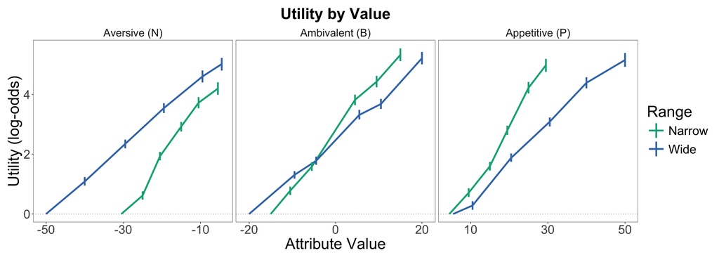

```r
# Attention weights and utilities of both range conditions.
weights_range   <- tibble()
utilities_range <- tibble()
for (rng in names(flex_draws)) {
  weights_range   <- bind_rows(weights_range,   summarise_flex_weights(rng))
  utilities_range <- bind_rows(utilities_range, summarise_flex_utilities(rng))
}

p_weights_data <- NULL
p_utilities    <- NULL
if (nrow(weights_range) > 0) {
  weights_range   <- weights_range   %>% mutate(WN = factor(WN, levels = c("Narrow", "Wide")))
  utilities_range <- utilities_range %>% mutate(WN = factor(WN, levels = c("Narrow", "Wide")))
  p_weights_data <- plot_by_range(weights_range,   "Data",             "Attention Weight", c(-0.5, 0.5))
  p_utilities    <- plot_by_range(utilities_range, "Utility by Value", "Utility (log-odds)")
}

# The value functions: utility of each value relative to the lowest value of
# its type. Not in the paper; saved next to the paper's figures for reference.
if (!is.null(p_utilities)) {
  ggsave(file.path(fig_dir, "attribute_level_utilities.pdf"), p_utilities, width = 2 * .figw, height = 1 * .figh)
}
p_utilities
```

### Bayesian model

The main Bayesian model: one prior per range condition, with loss aversion. Every trial’s choice probability is held out (12-fold cross-validation, blocks of five trial positions per subject, every fold fit from scratch), so the model never saw the trial it predicts. Ten replicates of one choice per trial are drawn from those probabilities, and each replicate is run through the same regression as the data, with the same brms model, priors and sampler, as its own dataset (so the hierarchical model sees the data’s design), on Compute Canada (`code/fitting/compute_canada_attention_weights.R`; `bayesian_model.Rmd` does the same for every model variant). Only a compact summary of each fit comes back, `notebooks/brm_fits/attention_weights_utility_sim_cond_lam_<range>_rep<k>_draws.rds`. The chunk pools the replicates by stacking their draws (the average of their posteriors) and takes the median and 95% HDI of every cell weight; the overlay draws only the medians.

```r
# The held-out predictions of the main model; the Extra Analyses section
# reads them for the participants' log-likelihoods.
bayes_loo_file <- file.path(bayes_dir, "loo_cond_lam.rds")

# The cluster fits of the main model's simulated choices: one file per
# replicate and range condition, holding the population-level draws of the
# same brms model as the data's. The replicates' draws are stacked (the
# average of their posteriors); posterior median and 95% HDI of every cell
# weight, parsed into type and value.
weights_model <- tibble()
for (rng in c("Narrow", "Wide")) {
  files <- list.files(fit_dir, full.names = TRUE,
                      pattern = paste0("^attention_weights_utility_sim_cond_lam_", tolower(rng), "_rep[0-9]+_draws\\.rds$"))
  if (length(files) == 0) { cat("No cluster fit for cond_lam", rng, "in", fit_dir, "\n"); next }
  cat(rng, ": ", length(files), " replicate(s)\n", sep = "")
  draws <- bind_rows(lapply(files, function(f) as_tibble(readRDS(f)$draws) %>% select(matches("^b_"))))
  for (cell in names(draws) %>% str_subset("^b_[PNB]_(neg|pos)[0-9]+$") %>% str_remove("^b_")) {
    x <- draws[[paste0("b_", cell)]]
    h <- bayestestR::hdi(x, ci = 0.95)
    weights_model <- bind_rows(weights_model, tibble(WN = rng, cell = cell, estimate = median(x), lo = h$CI_low, hi = h$CI_high))
  }
}
```

```
## Narrow: 10 replicate(s)
## Wide: 10 replicate(s)
```

```r
if (nrow(weights_model) > 0) {
  weights_model <- weights_model %>% mutate(WN = factor(WN, levels = c("Narrow", "Wide"))) %>% parse_cells()
}

# The right panel of the figure.
p_weights_model <- NULL
if (nrow(weights_model) > 0) {
  p_weights_model <- plot_by_range(weights_model, "Bayesian Model", "Attention Weight", c(-0.5, 0.5))
}
```

### Combined figure

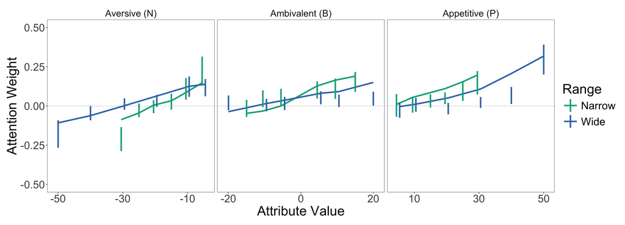

```r
# Data (points with 95% HDIs, from the brms fits) and the Bayesian model
# (lines: posterior medians of the same brms model on its out-of-sample simulated choices),
# Narrow and Wide overlaid in one panel. Only saved when both exist, so a
# figures-only pass without the caches doesn't overwrite the paper's figure.
fig_attr <- NULL
if (nrow(weights_range) > 0 && nrow(weights_model) > 0) {
  fig_attr <- plot_overlay(weights_range, weights_model, NULL, "Attention Weight", c(-0.5, 0.5))
  ggsave(file.path(fig_dir, "attribute_level_attention.pdf"), fig_attr, width = 2 * .figw, height = 1 * .figh)
}
fig_attr
```

## Tables

Population-level coefficients of the two brms fits (posterior median and 95% HDI) in one table: Narrow and Wide are the columns, the utilities (with the intercept and the Study 2 term) are Panel A and the attention weights Panel B. Rows are aligned by cell, so a value that only one range shows is blank in the other column. The Bayesian R2 takes a minute or two per fit.

```r
if (RUN_REGRESSIONS && length(flex_draws) == 2) {
  panel_a <- list()
  panel_b <- list()
  sds     <- list()
  for (rng in c("Narrow", "Wide")) {
    fit   <- flex_fit_range[[rng]]
    coefs <- order_cells(tidy_brms(fit))
    is_w  <- str_detect(coefs$term, "^[PNB]_(neg|pos)[0-9]+$")   # the attention weights
    # The fit statistics go under Panel B, at the bottom of the table.
    panel_a[[rng]] <- table_columns(coefs[!is_w, ], tibble(), c("ref" = rng))[[1]]
    panel_b[[rng]] <- table_columns(coefs[is_w, ],  gof_brms(fit), c("ref" = rng))[[1]]
    s <- sds_brms(fit)
    sds[[paste0(rng, ", utilities")]] <- s[str_detect(names(s), "^U_")]
    sds[[paste0(rng, ", weights")]]   <- s[!str_detect(names(s), "^U_")]
  }
  tab <- list(
    "Panel A: Utility of each value, relative to the lowest value of its type" = panel_a,
    "Panel B: Attention weight per second of dwell"                            = panel_b
  )
  # Rows in type and value order over the union of both ranges' cells (left to
  # itself, modelsummary would put the Wide-only values at the bottom).
  all_cells <- unique(unlist(lapply(flex_draws, function(d) {
    names(d) %>% str_subset("^b_[PNB]_(neg|pos)[0-9]+$") %>% str_remove("^b_")
  })))
  row_order <- c("Intercept", "Study 2", label_term(all_cells[cell_order(all_cells)]))
  save_tex(tab, "attribute_level_attention",
           sd_note(sds, intro = "Random-effect SDs across subjects (posterior medians)."),
           ci_inline = TRUE, coef_order = row_order)
}
```

## Text Output

```r
# One attention weight in the paper's notation: range condition in the
# superscript, attribute type in the subscript, the value in parentheses, e.g.
# omega_label("\\text{Narrow}", "N_neg30") -> \omega^{\text{Narrow}}_{\text{N}}(-30).
omega_label <- function(sup, cell) {
  v <- str_extract(cell, "[0-9]+$")
  if (str_detect(cell, "_neg")) v <- paste0("-", v)
  paste0("\\omega^{", sup, "}_{\\text{", str_sub(cell, 1, 1), "}}(", v, ")")
}

# One snippet from the cells of each range, e.g.
# list(Narrow = c("N_neg30", "N_neg25"), Wide = c("N_neg50", "N_neg40")) ->
# "$\omega^{\text{Narrow}}_{\text{N}}(-30) = -0.211\ [-0.287, -0.134]$, ...",
# the Narrow cells first, each range's cells in the order given. A named
# vector with one cell per range works too.
omega_text <- function(cells, digits = 3) {
  out <- c()
  for (rng in names(cells)) {
    for (cell in cells[[rng]]) {
      out <- c(out, paste0("$", omega_label(paste0("\\text{", rng, "}"), cell), " = ",
                           fmt_post(aw_draws(rng, cell), digits), "$"))
    }
  }
  paste(out, collapse = ", ")
}

# The Narrow minus Wide difference of one cell's weight: the two fits are
# independent, so the difference of draws is the posterior of the difference.
omega_diff_text <- function(cell, digits = 3) {
  paste0("$", omega_label("\\text{Narrow} - \\text{Wide}", cell), " = ",
         fmt_post(aw_draws("Narrow", cell) - aw_draws("Wide", cell), digits), "$")
}

# The difference between two attribute types at the values they share, e.g.
# omega_type_diff_text("B", "P") -> "$\omega^{\text{Narrow}}_{\text{B} - \text{P}}(5) = ...$, ...":
# type a minus type b, at every value both types take in a range (from the
# design), Narrow first. Both weights come from the same range's fit, so the
# difference of draws is the posterior of the difference.
cell_name <- function(type, value) paste0(type, "_", if_else(value < 0, "neg", "pos"), abs(value))
omega_type_diff_text <- function(a, b, digits = 3) {
  out <- c()
  for (rng in c("Narrow", "Wide")) {
    vals <- boxlong %>% filter(WN == rng) %>% distinct(type, value)
    shared <- sort(intersect(vals$value[vals$type == a], vals$value[vals$type == b]))
    for (v in shared) {
      d <- aw_draws(rng, cell_name(a, v)) - aw_draws(rng, cell_name(b, v))
      out <- c(out, paste0("$\\omega^{\\text{", rng, "}}_{\\text{", a, "} - \\text{", b, "}}(", v, ") = ",
                           fmt_post(d, digits), "$"))
    }
  }
  paste(out, collapse = ", ")
}
write_attn <- RUN_REGRESSIONS && length(flex_draws) == 2
```

```r
if (write_attn) {
  # The two lowest aversive values of each range: -30, -25 (Narrow); -50, -40 (Wide).
  save_text(omega_text(list(Narrow = c("N_neg30", "N_neg25"), Wide = c("N_neg50", "N_neg40"))), "attn_N_lowest")
  # The two middle values: -20, -15 (Narrow); -30, -20 (Wide).
  save_text(omega_text(list(Narrow = c("N_neg20", "N_neg15"), Wide = c("N_neg30", "N_neg20"))), "attn_N_middle")
  # The two highest (still negative) values, -10 and -5 in both ranges.
  save_text(omega_text(list(Narrow = c("N_neg10", "N_neg5"), Wide = c("N_neg10", "N_neg5"))), "attn_N_highest")
  # The maximum aversive value on its own, -5 in both ranges.
  save_text(omega_text(c(Narrow = "N_neg5", Wide = "N_neg5")), "attn_N_max")
  # The one middle value whose interval does not include 0: -40 in Wide.
  save_text(omega_text(c(Wide = "N_neg40")), "attn_N_neg40_wide")
  # -30 is the lowest value in Narrow but a middle value in Wide: each range's
  # weight, and the Narrow minus Wide difference.
  save_text(omega_text(c(Narrow = "N_neg30")), "attn_N_neg30_narrow")
  save_text(omega_text(c(Wide = "N_neg30")), "attn_N_neg30_wide")
  save_text(omega_diff_text("N_neg30"), "attn_N_neg30_diff")
}
```

```r
if (write_attn) {
  # The two highest appetitive values of each range: 25, 30 (Narrow); 40, 50 (Wide).
  save_text(omega_text(list(Narrow = c("P_pos25", "P_pos30"), Wide = c("P_pos40", "P_pos50"))), "attn_P_highest")
  # A middle appetitive value: 20 (Narrow), 30 (Wide).
  save_text(omega_text(c(Narrow = "P_pos20", Wide = "P_pos30")), "attn_P_middle")
  # The two lowest appetitive values, 5 and 10 in both ranges.
  save_text(omega_text(list(Narrow = c("P_pos5", "P_pos10"), Wide = c("P_pos5", "P_pos10"))), "attn_P_lowest")
  # The minimum appetitive value on its own, 5 in both ranges.
  save_text(omega_text(c(Narrow = "P_pos5", Wide = "P_pos5")), "attn_P_min")
  # 30 is the highest value in Narrow but a middle value in Wide: the Narrow
  # minus Wide difference.
  save_text(omega_diff_text("P_pos30"), "attn_P_pos30_diff")
}
```

```r
if (write_attn) {
  # Ambivalent minus appetitive at the positive values both types take
  # (5, 10, 15 in Narrow; 5, 10, 20 in Wide), and ambivalent minus aversive at
  # the negative values both take (-15, -10, -5 in Narrow; -20, -10, -5 in Wide).
  save_text(omega_type_diff_text("B", "P"), "attn_B_P_compare")
  save_text(omega_type_diff_text("B", "N"), "attn_B_N_compare")
}
```

# Range Sensitivity

A value-representation test rather than an attention test: does a given value difference move choice more in the Narrow range than in the Wide range? Choice is regressed on the three per-type value channels, each crossed with range and study, with subject-level random intercepts and slopes on the three channels. Range normalization predicts steeper slopes in Narrow. This model has only four random effects per subject, so like the other small models it is fit by maximum likelihood (glmmTMB) rather than brms.

```r
# Signed value per type (value only, no dwell time), for every trial.
value_design <- boxlong %>%
  group_by(Subject, Trial, type) %>%
  summarise(SV = sum(signed_value), .groups = "drop") %>%
  pivot_wider(names_from = type, values_from = SV, names_prefix = "SV_", values_fill = 0)

val_dat <- pas %>%
  transmute(Study = factor(Study), Subject, Trial, ChooseL, WN) %>%
  left_join(value_design, by = c("Subject", "Trial"))

fit_val <- glmmTMB(
  ChooseL ~ (SV_P + SV_N + SV_B) * WN * Study + (1 + SV_P + SV_N + SV_B | Subject),
  data = val_dat, family = binomial
)
```

```r
# Narrow and Study 1 are the reference levels, so each (type, range, study)
# slope is a sum of coefficients:
#   Narrow, Study 1: b_SV
#   Wide,   Study 1: b_SV + b_SV:WNWide
#   Narrow, Study 2: b_SV + b_SV:Study2
#   Wide,   Study 2: b_SV + b_SV:WNWide + b_SV:Study2 + b_SV:WNWide:Study2
# "Wide - Narrow" is the Wide terms that are not in the Narrow sum.
slopes <- tibble()
for (s in 1:2) {
  for (tt in c("N", "B", "P")) {
    sv <- paste0("SV_", tt)
    narrow_terms <- c(sv, if (s == 2) paste0(sv, ":Study2"))
    wide_terms   <- c(narrow_terms, paste0(sv, ":WNWide"), if (s == 2) paste0(sv, ":WNWide:Study2"))
    for (q in c("Narrow", "Wide", "Wide - Narrow")) {
      terms <- switch(q, "Narrow" = narrow_terms, "Wide" = wide_terms,
                      "Wide - Narrow" = setdiff(wide_terms, narrow_terms))
      ci <- coef_ci(fit_val, terms)
      slopes <- bind_rows(slopes, tibble(
        Study = paste0("Study ", s), type = tt, quantity = q,
        estimate = ci[["estimate"]], lo = ci[["lo"]], hi = ci[["hi"]]
      ))
    }
  }
}
slopes <- slopes %>% mutate(type = factor(type, levels = c("N", "B", "P")))

slopes %>% mutate(across(c(estimate, lo, hi), \(x) round(x, 3)))
```

```
## # A tibble: 18 × 6
##    Study   type  quantity      estimate     lo     hi
##    <chr>   <fct> <chr>            <dbl>  <dbl>  <dbl>
##  1 Study 1 N     Narrow           1.93   1.84   2.02
##  2 Study 1 N     Wide             1.47   1.39   1.55
##  3 Study 1 N     Wide - Narrow   -0.46  -0.577 -0.342
##  4 Study 1 B     Narrow           1.85   1.76   1.93
##  5 Study 1 B     Wide             1.56   1.48   1.64
##  6 Study 1 B     Wide - Narrow   -0.286 -0.398 -0.174
##  7 Study 1 P     Narrow           2.12   2.02   2.22
##  8 Study 1 P     Wide             1.58   1.49   1.66
##  9 Study 1 P     Wide - Narrow   -0.546 -0.67  -0.421
## 10 Study 2 N     Narrow           1.95   1.84   2.06
## 11 Study 2 N     Wide             1.30   1.22   1.39
## 12 Study 2 N     Wide - Narrow   -0.645 -0.782 -0.507
## 13 Study 2 B     Narrow           1.84   1.74   1.93
## 14 Study 2 B     Wide             1.38   1.29   1.47
## 15 Study 2 B     Wide - Narrow   -0.454 -0.583 -0.325
## 16 Study 2 P     Narrow           2.12   2.01   2.24
## 17 Study 2 P     Wide             1.35   1.26   1.45
## 18 Study 2 P     Wide - Narrow   -0.767 -0.913 -0.621
```

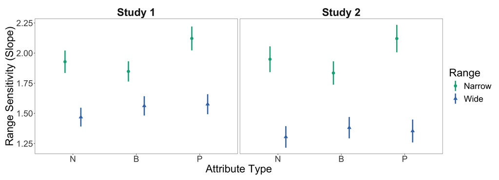

```r
pdata_val <- slopes %>%
  filter(quantity %in% c("Narrow", "Wide")) %>%
  mutate(WN = factor(quantity, levels = c("Narrow", "Wide")),
         Study = str_remove(Study, "Study "))

p_val <- ggplot(pdata_val, aes(x = type, y = estimate, color = WN, shape = WN)) +
  facet_wrap(~ Study, labeller = study_labels) +
  geom_pointrange(aes(ymin = lo, ymax = hi), size = 0.8, linewidth = .linewidth,
                  position = position_dodge(width = 0.5)) +
  wn_scales +
  labs(x = "Attribute Type", y = "Range Sensitivity (Slope)") + #(log-odds per 10 points)
  .myPlot + strip_style + legend_right + theme(legend.direction = "vertical")

# 1 row x 2 columns (Study 1, Study 2).
ggsave(file.path(fig_dir, "range_sensitivity.pdf"), p_val, width = 2 * .figw, height = 1 * .figh)
p_val
```

## Table

```r
if (RUN_REGRESSIONS) {
  save_tex(freq_columns(fit_val, "Frequentist (glmmTMB)"), "range_sensitivity",
           sd_note(list(sds_freq(fit_val))))
}
```

## Text Output

The statistic quoted in the Range Sensitivity paragraph of the paper.

```r
if (RUN_REGRESSIONS) {
  # Wide minus Narrow value sensitivity (log-odds per 10 points) per type and
  # study, taken from the `slopes` table above (the SV x WNWide interaction,
  # plus its Study2 interaction for Study 2).
  out <- c()
  for (s in 1:2) {
    for (tt in c("N", "B", "P")) {
      r <- slopes %>% filter(Study == paste("Study", s), type == tt, quantity == "Wide - Narrow")
      out <- c(out, paste0("$\\Delta^{\\text{Wide - Narrow}, ", tt, "}_{\\text{Study ", s, "}} = ",
                           fmt_ci(r$estimate, r$lo, r$hi), "$"))
    }
  }
  # One statistic per line (a blank line between them).
  save_text(paste(out, collapse = "\n\n"), "range_sensitivity_diff")
}
```

# Extra Analyses

Analyses that are not in the paper, kept in case we want them again. Nothing in this section runs unless the switch below is TRUE.

```r
run_extra_analyses <- FALSE
```

## Attention weights with linear value channels, by study (pre-registered)

The pre-registered attention-weight model, which the paper used as its main model before the per-value utilities (see the Attribute-Level Attention section): the three signed values enter as linear channels (`SV_P`, `SV_N`, `SV_B`) instead of one utility per value, and every coefficient is crossed with study (Study 1 is the reference level, so a Study 2 weight is the Study 1 weight plus the cell’s `:Study2` interaction). Because it was pre-registered it is reported in the last supplementary section of the paper, so this subsection writes its figure (`paper/figures/attribute_level_attention_preregistered.pdf`) and its two tables (`paper/tables/attribute_level_attention_weights_preregistered_narrow.tex` and `_wide.tex`) when the switch above is on.

```r
if (run_extra_analyses) {
  # Like build_flex_dat(), with the three signed value channels in place of
  # the utility columns.
  build_flex_dat_linear <- function(range, bl = boxlong, ps = pas) {
    bl <- bl %>% filter(WN == range)
    ps <- ps %>% filter(WN == range)
    dwell_design <- bl %>%
      group_by(Subject, Trial, cell) %>%
      summarise(sd = sum(signed_dwell), .groups = "drop") %>%
      pivot_wider(names_from = cell, values_from = sd, values_fill = 0)
    # Signed value per attribute type. These three sum to Diff / 10.
    value_design <- bl %>%
      group_by(Subject, Trial, type) %>%
      summarise(SV = sum(signed_value), .groups = "drop") %>%
      pivot_wider(names_from = type, values_from = SV, names_prefix = "SV_", values_fill = 0)
    ps %>%
      transmute(Subject, Trial, ChooseL, Study = factor(Study)) %>%
      left_join(value_design, by = c("Subject", "Trial")) %>%
      left_join(dwell_design, by = c("Subject", "Trial"))
  }

  # Every value channel and cell weight crossed with study, plus subject-level
  # random slopes on the value channels and on every cell.
  build_flex_formula_linear <- function(dat) {
    value_cols <- c("SV_P", "SV_N", "SV_B")
    as.formula(paste(
      "ChooseL ~ (", paste(c(value_cols, dwell_cols(dat)), collapse = " + "), ") * Study",
      "+ (0 + SV_P + SV_N + SV_B | Subject)",
      "+ (0 +", paste(dwell_cols(dat), collapse = " + "), "| Subject)"
    ))
  }

  linear_files <- c(
    Narrow = "flex_attention_weights_pooled_narrow",
    Wide   = "flex_attention_weights_pooled_wide"
  )
  linear_fit <- list()
  for (rng in c("Narrow", "Wide")) {
    linear_dat <- build_flex_dat_linear(rng)
    linear_fit[[rng]] <- load_or_fit(
      linear_files[[rng]],
      formula = build_flex_formula_linear(linear_dat),
      data    = linear_dat,
      family  = bernoulli(),
      prior   = brms_priors,
      chains  = BRMS_CHAINS, iter = 4000, seed = BRMS_SEED,
      control = list(adapt_delta = 0.95, max_treedepth = 12)
    )
  }
}
```

```r
if (run_extra_analyses) {
  linear_draws <- list()
  for (rng in names(linear_fit)) {
    if (!is.null(linear_fit[[rng]])) {
      linear_draws[[rng]] <- as_draws_df(linear_fit[[rng]], variable = "^b_", regex = TRUE)
    }
  }

  # Draws of one cell weight for one study, e.g. aw_draws_linear("Narrow", "N_neg30", 2).
  aw_draws_linear <- function(range, cell, study) {
    d <- linear_draws[[range]]
    if (study == 1) d[[paste0("b_", cell)]] else d[[paste0("b_", cell)]] + d[[paste0("b_", cell, ":Study2")]]
  }

  # Median and 95% HDI of every cell weight, by range and study.
  weights_linear <- tibble()
  for (rng in names(linear_draws)) {
    cells <- names(linear_draws[[rng]]) %>% str_subset("^b_[PNB]_(neg|pos)[0-9]+$") %>% str_remove("^b_")
    for (s in 1:2) {
      for (cell in cells) {
        x <- aw_draws_linear(rng, cell, s)
        h <- bayestestR::hdi(x, ci = 0.95)
        weights_linear <- bind_rows(weights_linear, tibble(
          Study = s, WN = rng, cell = cell, estimate = median(x), lo = h$CI_low, hi = h$CI_high
        ))
      }
    }
  }

  # One panel per study, Narrow and Wide overlaid. Saved for the supplement.
  p_linear <- list()
  if (nrow(weights_linear) > 0) {
    weights_linear <- parse_cells(weights_linear) %>% mutate(WN = factor(WN, levels = c("Narrow", "Wide")))
    for (s in 1:2) {
      key <- paste0("Study ", s)
      p_linear[[key]] <- plot_by_range(weights_linear %>% filter(Study == s), key, "Attention Weight", c(-0.5, 0.5))
    }
  }
  fig_linear <- (get_or_spacer(p_linear, "Study 1") | get_or_spacer(p_linear, "Study 2")) + plot_layout(guides = "collect")
  if (length(p_linear) == 2) {
    ggsave(file.path(fig_dir, "attribute_level_attention_preregistered.pdf"), fig_linear, width = 2 * .figw, height = 1 * .figh)
  }
  fig_linear
}
```

```r
if (run_extra_analyses) {
  # One table per range: the Study 1 coefficient and its Study 2 interaction.
  # These are the file names the paper's supplement inputs.
  for (rng in c("Narrow", "Wide")) {
    fit  <- linear_fit[[rng]]
    tab  <- table_columns(order_cells(tidy_brms(fit)), gof_brms(fit), study_columns)
    note <- sd_note(list(sds_brms(fit)), intro = "Random-effect SDs across subjects (posterior medians).")
    save_tex(tab, paste0("attribute_level_attention_weights_preregistered_", tolower(rng)), note, ci_inline = TRUE)
  }
}
```

```r
if (run_extra_analyses && length(linear_draws) == 2) {
  # How well the two studies agree in the pre-registered model, quoted in the
  # supplement: the correlation between the Study 1 and Study 2 cell weights
  # across all 36 cells (18 per range), and how many of the 36 cell x Study 2
  # interactions have a 95% HDI that excludes 0 (1.8 expected by chance).
  by_study <- weights_linear %>%
    select(WN, cell, Study, estimate) %>%
    pivot_wider(names_from = Study, values_from = estimate, names_prefix = "S")
  n_excl <- 0
  for (rng in names(linear_draws)) {
    d <- linear_draws[[rng]]
    for (v in names(d) %>% str_subset("^b_[PNB]_(neg|pos)[0-9]+:Study2$")) {
      h <- bayestestR::hdi(d[[v]], ci = 0.95)
      if (h$CI_low > 0 || h$CI_high < 0) n_excl <- n_excl + 1
    }
  }
  save_text(sprintf("$r = %.2f$ across the %d cells; %d of %d $\\times$ Study 2 interactions exclude 0",
                    cor(by_study$S1, by_study$S2), nrow(by_study), n_excl, nrow(by_study)),
            "attn_prereg_agreement")
}
```

## Attention weights by study (utility model)

Robustness check for pooling the two studies in the main model: the same per-value-utility model as the Attribute-Level Attention section, with every population-level coefficient (the intercept, the 15 utilities, and the 18 attention weights) crossed with study. Study 1 is the reference level, so a Study 2 coefficient is the Study 1 coefficient plus its `:Study2` interaction. The random slopes are those of the main model (uncorrelated on the utilities, correlated on the weights). One fit per range condition, sampled from a terminal with `code/fitting/sample_bystudy_attention_weights.R` (many hours each). When the switch above is on, this subsection writes the figure (`paper/figures/attribute_level_attention_by_study.pdf`), the two tables (`paper/tables/attribute_level_attention_by_study_narrow.tex` and `_wide.tex`) and the snippets (`attn_bystudy_corr`, `attn_bystudy_siginteractions`, and `util_bystudy_siginteractions` for the utility interactions) of the paper’s “Attention Weights by Study” supplementary section.

Both fits were sampled on 4-5 November 2026 (7.4 and 6.0 hours). They are clean on every population-level parameter (no divergences, no treedepth hits, Rhat at most 1.003, bulk ESS at least 2,500); a few subject-level correlations in Wide mix more slowly (one Rhat of 1.04 with a bulk ESS of 119), and nothing below uses them. The Study 1 and Study 2 weights correlate at 0.77 across the 36 cells, and 5 of the 36 weight interactions exclude 0 (1.8 by chance): the lowest aversive value in Wide (-0.305 in Study 1, -0.072 in Study 2), the two lowest ambivalent values in Narrow, and the 20 and 30 appetitive values in Wide. The utilities differ more between the studies: 8 of the 30 utility interactions exclude 0, all in Wide, where Study 2’s utilities rise more steeply over the lowest aversive values and less steeply over the upper ambivalent and appetitive values.

```r
if (run_extra_analyses) {
  # The main model's design matrix (build_flex_dat() keeps Study as a factor);
  # the Study 2 intercept term S2 is replaced by the Study interactions.
  build_flex_formula_bystudy <- function(dat) {
    as.formula(paste(
      "ChooseL ~ (1 +", paste(c(util_cols(dat), dwell_cols(dat)), collapse = " + "), ") * Study",
      "+ (0 +", paste(util_cols(dat),  collapse = " + "), "|| Subject)",
      "+ (0 +", paste(dwell_cols(dat), collapse = " + "), "| Subject)"
    ))
  }

  bystudy_files <- c(
    Narrow = "attention_weights_utility_bystudy_narrow",
    Wide   = "attention_weights_utility_bystudy_wide"
  )
  # The terminal script can set bystudy_ranges to a single range before running this chunk.
  if (!exists("bystudy_ranges")) bystudy_ranges <- c("Narrow", "Wide")

  bystudy_fit <- list()
  for (rng in bystudy_ranges) {
    bystudy_dat <- build_flex_dat(rng) %>% select(-S2)
    bystudy_fit[[rng]] <- load_or_fit(
      bystudy_files[[rng]],
      formula = build_flex_formula_bystudy(bystudy_dat),
      data    = bystudy_dat,
      family  = bernoulli(),
      prior   = brms_priors,
      chains  = BRMS_CHAINS, iter = 4000, seed = BRMS_SEED,
      control = list(adapt_delta = 0.95, max_treedepth = 12)
    )
  }
}
```

```r
if (run_extra_analyses) {
  bystudy_draws <- list()
  for (rng in names(bystudy_fit)) {
    if (!is.null(bystudy_fit[[rng]])) {
      bystudy_draws[[rng]] <- as_draws_df(bystudy_fit[[rng]], variable = "^b_", regex = TRUE)
    }
  }

  # Draws of one coefficient for one study: the Study 1 draw, or the Study 1
  # draw plus its Study 2 interaction. `par` is an attention weight such as
  # "N_neg30" or a utility such as "U_N_neg25".
  bystudy_draws_of <- function(range, par, study) {
    d <- bystudy_draws[[range]]
    if (study == 1) d[[paste0("b_", par)]] else d[[paste0("b_", par)]] + d[[paste0("b_", par, ":Study2")]]
  }

  # Median and 95% HDI of every attention weight and every utility, by range
  # and study. As in the main model's figures, each type's reference (lowest)
  # value is put back at 0 for the utilities.
  weights_bystudy   <- tibble()
  utilities_bystudy <- tibble()
  for (rng in names(bystudy_draws)) {
    pars <- names(bystudy_draws[[rng]]) %>% str_subset("^b_(U_)?[PNB]_(neg|pos)[0-9]+$") %>% str_remove("^b_")
    refs <- boxlong %>%
      filter(WN == rng) %>%
      distinct(type, value, cell) %>%
      group_by(type) %>%
      slice_min(value, n = 1) %>%
      ungroup() %>%
      pull(cell)
    for (s in 1:2) {
      for (par in pars) {
        x   <- bystudy_draws_of(rng, par, s)
        h   <- bayestestR::hdi(x, ci = 0.95)
        row <- tibble(Study = s, WN = rng, cell = str_remove(par, "^U_"),
                      estimate = median(x), lo = h$CI_low, hi = h$CI_high)
        if (str_detect(par, "^U_")) {
          utilities_bystudy <- bind_rows(utilities_bystudy, row)
        } else {
          weights_bystudy <- bind_rows(weights_bystudy, row)
        }
      }
      utilities_bystudy <- bind_rows(utilities_bystudy,
                                     tibble(Study = s, WN = rng, cell = refs, estimate = 0, lo = 0, hi = 0))
    }
  }

  # One panel per study, Narrow and Wide overlaid: the attention weights (for
  # the supplement) and the utilities (saved for reference).
  p_w <- list()
  p_u <- list()
  if (nrow(weights_bystudy) > 0) {
    weights_bystudy   <- parse_cells(weights_bystudy)   %>% mutate(WN = factor(WN, levels = c("Narrow", "Wide")))
    utilities_bystudy <- parse_cells(utilities_bystudy) %>% mutate(WN = factor(WN, levels = c("Narrow", "Wide")))
    for (s in 1:2) {
      key <- paste0("Study ", s)
      p_w[[key]] <- plot_by_range(weights_bystudy   %>% filter(Study == s), key, "Attention Weight", c(-0.5, 0.5))
      p_u[[key]] <- plot_by_range(utilities_bystudy %>% filter(Study == s), key, "Utility (log-odds)")
    }
  }
  fig_bystudy_weights   <- (get_or_spacer(p_w, "Study 1") | get_or_spacer(p_w, "Study 2")) + plot_layout(guides = "collect")
  fig_bystudy_utilities <- (get_or_spacer(p_u, "Study 1") | get_or_spacer(p_u, "Study 2")) + plot_layout(guides = "collect")
  if (length(p_w) == 2) {
    ggsave(file.path(fig_dir, "attribute_level_attention_by_study.pdf"), fig_bystudy_weights,   width = 2 * .figw, height = 1 * .figh)
    ggsave(file.path(fig_dir, "attribute_level_utilities_by_study.pdf"), fig_bystudy_utilities, width = 2 * .figw, height = 1 * .figh)
  }
  print(fig_bystudy_weights)
  fig_bystudy_utilities
}
```

```r
if (run_extra_analyses) {
  # One table per range, laid out like the main table (Panel A utilities,
  # Panel B weights) but with the Study 1 coefficient and its Study 2
  # interaction as the columns. These are the files the supplement inputs.
  for (rng in names(bystudy_fit)) {
    fit <- bystudy_fit[[rng]]
    if (is.null(fit)) next
    coefs <- order_cells(tidy_brms(fit))
    is_w  <- str_detect(coefs$term, "^[PNB]_(neg|pos)[0-9]+(:Study2)?$")   # the attention weights
    # The fit statistics go under Panel B only. table_columns() gives the
    # second column a placeholder Num.Obs. row, which would print as an empty
    # row under Panel A, so Panel A's columns get no fit statistics at all.
    panel_a <- table_columns(coefs[!is_w, ], tibble(), study_columns)
    for (k in seq_along(panel_a)) panel_a[[k]]$glance <- tibble()
    tab <- list(
      "Panel A: Utility of each value, relative to the lowest value of its type" = panel_a,
      "Panel B: Attention weight per second of dwell" =
        table_columns(coefs[is_w, ], gof_brms(fit), study_columns)
    )
    s    <- sds_brms(fit)
    note <- sd_note(list("Utilities" = s[str_detect(names(s), "^U_")], "Weights" = s[!str_detect(names(s), "^U_")]),
                    intro = "Random-effect SDs across subjects (posterior medians).")
    save_tex(tab, paste0("attribute_level_attention_by_study_", tolower(rng)), note, ci_inline = TRUE)
  }
}
```

```r
if (run_extra_analyses && length(bystudy_draws) == 2) {
  # How well the two studies agree under the utility model, quoted in the
  # supplement: the correlation between the Study 1 and Study 2 attention
  # weights across all 36 cells (18 per range), and the Study 2 interactions
  # (36 on the weights, 30 on the utilities) whose 95% HDI excludes 0, each
  # with its posterior median and HDI (5% of each would by chance).
  by_study <- weights_bystudy %>%
    select(WN, cell, Study, estimate) %>%
    pivot_wider(names_from = Study, values_from = estimate, names_prefix = "S")
  # Pearson correlation of the 36 cell medians, with the p-value of its t-test (34 df).
  ct <- cor.test(by_study$S1, by_study$S2)
  save_text(sprintf("$r = %.2f$, $%s$", ct$estimate, fmt_p(ct$p.value)), "attn_bystudy_corr")

  # A Study 2 interaction in the paper's notation: range condition in the
  # superscript, attribute type and the Study 2 - Study 1 contrast in the
  # subscript, the value in parentheses, e.g.
  # \omega^{\text{Wide}}_{\text{N}, \text{Study 2} - \text{Study 1}}(-50);
  # a utility interaction uses u in place of \omega.
  bystudy_label <- function(rng, par) {
    sym  <- if (str_detect(par, "^U_")) "u" else "\\omega"
    cell <- str_remove(par, "^U_")
    v    <- str_extract(cell, "[0-9]+$")
    if (str_detect(cell, "_neg")) v <- paste0("-", v)
    paste0(sym, "^{\\text{", rng, "}}_{\\text{", str_sub(cell, 1, 1), "}, \\text{Study 2} - \\text{Study 1}}(", v, ")")
  }

  # Narrow first, then Wide; within a range, the cells in type and value order.
  n_excl <- c(weights = 0, utilities = 0)
  n_tot  <- c(weights = 0, utilities = 0)
  sig    <- list(weights = c(), utilities = c())
  for (rng in names(bystudy_draws)) {
    d    <- bystudy_draws[[rng]]
    pars <- names(d) %>% str_subset("^b_(U_)?[PNB]_(neg|pos)[0-9]+:Study2$") %>% str_remove("^b_") %>% str_remove(":Study2$")
    for (par in pars[cell_order(pars)]) {
      x <- d[[paste0("b_", par, ":Study2")]]
      h <- bayestestR::hdi(x, ci = 0.95)
      k <- if (str_detect(par, "^U_")) "utilities" else "weights"
      n_tot[[k]] <- n_tot[[k]] + 1
      if (h$CI_low > 0 || h$CI_high < 0) {
        n_excl[[k]] <- n_excl[[k]] + 1
        sig[[k]]    <- c(sig[[k]], paste0("$", bystudy_label(rng, par), " = ", fmt_post(x), "$"))
      }
    }
  }
  cat(sprintf("%d of %d weight and %d of %d utility interactions exclude 0\n",
              n_excl[["weights"]], n_tot[["weights"]], n_excl[["utilities"]], n_tot[["utilities"]]))
  save_text(paste(sig$weights,   collapse = ", "), "attn_bystudy_siginteractions")
  save_text(paste(sig$utilities, collapse = ", "), "util_bystudy_siginteractions")
}
```

## Attention weights pooled across range conditions

The cell-weight model from the Attribute-Level Attention section, but fit per study on both range conditions together (so a cell’s weight is averaged over the two ranges it can appear in), without study interactions. These were the fits used before the by-range models. The cached fits keep the file names from the original per-study notebooks.

```r
if (run_extra_analyses) {
  # Like build_flex_dat(), but one study, both ranges, and no Study column.
  build_flex_dat_allranges <- function(study) {
    bl <- boxlong %>% filter(Study == study)
    ps <- pas     %>% filter(Study == study)
    flex_design <- bl %>%
      group_by(Subject, Trial, cell) %>%
      summarise(sd = sum(signed_dwell), .groups = "drop") %>%
      pivot_wider(names_from = cell, values_from = sd, values_fill = 0)
    value_design <- bl %>%
      group_by(Subject, Trial, type) %>%
      summarise(SV = sum(signed_value), .groups = "drop") %>%
      pivot_wider(names_from = type, values_from = SV, names_prefix = "SV_", values_fill = 0)
    ps %>%
      select(Subject, Trial, ChooseL) %>%
      left_join(value_design, by = c("Subject", "Trial")) %>%
      left_join(flex_design,  by = c("Subject", "Trial"))
  }

  # Like build_flex_formula(), without the study interactions.
  build_flex_formula_allranges <- function(dat) {
    value_cols <- c("SV_P", "SV_N", "SV_B")
    cell_cols  <- setdiff(names(dat), c("Subject", "Trial", "ChooseL", value_cols))
    as.formula(paste(
      "ChooseL ~", paste(value_cols, collapse = " + "), "+",
      paste(cell_cols, collapse = " + "),
      "+ (0 + SV_P + SV_N + SV_B | Subject)",
      "+ (0 +", paste(cell_cols, collapse = " + "), "| Subject)"
    ))
  }

  # The Study 1 fit was sampled with adapt_delta = 0.99, the Study 2 fit with 0.95.
  flex_files <- c(
    "Study 1" = "flex_attention_weights_typeval_partpool",
    "Study 2" = "PAS4_flex_attention_weights_typeval_partpool"
  )
  flex_fit <- list()
  for (s in 1:2) {
    key <- paste0("Study ", s)
    flex_dat <- build_flex_dat_allranges(s)
    flex_fit[[key]] <- load_or_fit(
      flex_files[[key]],
      formula = build_flex_formula_allranges(flex_dat),
      data    = flex_dat,
      family  = bernoulli(),
      prior   = brms_priors,
      chains  = BRMS_CHAINS, iter = 4000, seed = BRMS_SEED,
      control = list(adapt_delta = ifelse(s == 1, 0.99, 0.95), max_treedepth = 12)
    )
  }
}
```

```r
if (run_extra_analyses) {
  # Cell weights of one fit (no study interactions here, so tidy_brms is enough).
  summarise_flex_weights_allranges <- function(fit) {
    tidy_brms(fit) %>%
      filter(str_detect(term, "^[PNB]_(neg|pos)[0-9]+$")) %>%
      transmute(
        term, estimate, lo = conf.low, hi = conf.high,
        type  = factor(str_sub(term, 1, 1), levels = c("N", "B", "P")),
        value = as.numeric(str_extract(term, "[0-9]+$")) * if_else(str_detect(term, "_neg"), -1, 1)
      )
  }

  # Signed attention weights by type and value (one study). These fits pool the
  # two range conditions, so everything is drawn in black.
  plot_weights <- function(weights, title) {
    ggplot(weights, aes(x = value, y = estimate)) +
      facet_wrap(~ type, scales = "free_x", labeller = type_labels) +
      geom_hline(yintercept = 0, linetype = "dotted", color = "grey50") +
      geom_line(linewidth = .linewidth) +
      geom_pointrange(aes(ymin = lo, ymax = hi), size = pt_size, linewidth = .linewidth, color = "black") +
      labs(x = "Attribute Value", y = "Attention Weight", title = title) +
      .myPlot + type_strip_style + study_title + legend_right + theme(legend.direction = "vertical") +
      scale_x_continuous(breaks = x_attr_breaks)
  }

  p_weights <- list()
  for (key in names(flex_fit)) {
    if (!is.null(flex_fit[[key]])) {
      p_weights[[key]] <- plot_weights(summarise_flex_weights_allranges(flex_fit[[key]]), title = key)
    }
  }
  (get_or_spacer(p_weights, "Study 1") | get_or_spacer(p_weights, "Study 2"))
}
```

```r
if (run_extra_analyses) {
  # One column per study (these fits have no moderators, so every coefficient
  # is a "ref" one).
  tab <- list()
  sds <- list()
  for (key in names(flex_fit)) {
    fit <- flex_fit[[key]]
    tab <- c(tab, table_columns(order_cells(tidy_brms(fit)), gof_brms(fit), c("ref" = key)))
    sds[[key]] <- sds_brms(fit)
  }
  save_tex(tab, "attribute_level_attention_weights",
           sd_note(sds, intro = "Random-effect SDs across subjects (posterior medians)."), ci_inline = TRUE)
}
```

## Range sensitivity with brms

The range-sensitivity model fit with brms instead of glmmTMB (one fit per study, no study interactions), as in the earlier version of this notebook, kept for comparison with the glmmTMB fit above.

```r
if (run_extra_analyses) {
  val_files <- c(
    "Study 1" = "value_sensitivity_by_range",
    "Study 2" = "PAS4_value_sensitivity_by_range"
  )
  val_fit_brms <- list()
  for (s in 1:2) {
    key <- paste0("Study ", s)
    val_fit_brms[[key]] <- load_or_fit(
      val_files[[key]],
      formula = ChooseL ~ (SV_P + SV_N + SV_B) * WN + (1 + SV_P + SV_N + SV_B | Subject),
      data    = val_dat %>% filter(Study == s),
      family  = bernoulli(),
      prior   = brms_priors,
      chains  = BRMS_CHAINS, iter = 2000, seed = BRMS_SEED,
      control = list(adapt_delta = 0.95)
    )
  }
  lapply(val_fit_brms, tidy_brms)
}
```

## Participant-level out-of-sample log-likelihood of the Bayesian model

How large is the out-of-sample log-likelihood that one participant contributes to the model comparison (the table of estimates in the Bayesian model supplement)? A participant’s total is the sum, over all of their trials, of the log probability that the main Bayesian model gave to the choice they made, when it was fit without that trial (the 12-fold cross-validation of `bayesian_model.Rmd`; `heldout_loglik` clips each probability to [1e-12, 1 - 1e-12], as in that comparison, and the clip never binds). A total is a sum over trials, and Study 1 participants have 24 to 30 trials against 50 to 60 in Study 2, so the mean and SD of the totals are given for each study. Needs only the cached held-out predictions, so it is quick, but like the rest of this section it runs only when the switch is TRUE. Snippet: `bayes_participant_ll`.

```r
if (run_extra_analyses && file.exists(bayes_loo_file)) {
  # heldout_loglik lives in the Bayesian model's fitting code; load that file
  # into its own environment so that its helper names don't mix with this
  # notebook's.
  fit_code <- new.env()
  source(here::here("code/fitting/fit_bayesian_attributes.R"), local = fit_code)

  # One row per participant: the total log-likelihood over their trials.
  pred    <- readRDS(bayes_loo_file)$pred
  pred$ll <- fit_code$heldout_loglik(pred)
  ll_part <- pred %>%
    group_by(Subject, Study) %>%
    summarise(total = sum(ll), .groups = "drop")

  # Mean and SD of the participants' totals, one pair per study (the study goes
  # in the subscript).
  by_study <- c()
  for (s in 1:2) {
    x <- ll_part$total[ll_part$Study == s]
    by_study <- c(by_study, sprintf("$M_{\\text{Study %d}} = %.2f$, $SD_{\\text{Study %d}} = %.2f$", s, mean(x), s, sd(x)))
  }
  save_text(paste(by_study, collapse = "; "), "bayes_participant_ll")
}
```

## Convergence of the Bayesian regressions

Checks the two sentences in the paper’s Methods: every Bayesian model converged with no divergent transitions, and every group-level parameter and subject-level random effect had $\hat{R} < 1.01$ and an effective sample size above 1,000. “Group-level parameters” are the population-level coefficients (`b_`, the estimates the tables report); the subject-level random effects are the `r_` terms. Both the bulk and the tail effective sample size must clear 1,000, and $\hat{R}$ is compared after rounding to two decimals, as it would be reported, so a value that rounds to 1.01 passes and one that rounds to 1.02 does not. The random-effect SDs and correlations are not part of the claim and are not checked (several of them mix more slowly; see the by-study section above). The models are the six brms fits of the data whose estimates the paper reports (the main attention-weight model of the Attribute-Level Attention section, its by-study version and the pre-registered linear-channel version, one fit per range condition) and the fits of the main Bayesian model’s simulated choices that draw the model lines of the attribute-level figure; for those only the population-level draws and the sampler diagnostics were kept (see `code/fitting/compute_canada_attention_weights.R`), so their subject-level random effects cannot be checked. The table has one row per fit and level: the number of parameters, the divergent transitions, the largest $\hat{R}$, the smallest effective sample size and how many parameters miss either threshold; the parameters that miss one are listed after it, then the verdict. Every fit of the data is about 1.4 GB with tens of thousands of subject-level parameters, so this chunk is slow (about 17 minutes). Snippet: `brms_convergence`, the largest $\hat{R}$ and the smallest effective sample size over the checked parameters.

```r
if (run_extra_analyses) {
  # The fits of the data that the paper reports, one per range condition.
  paper_fits <- c(
    "Main, Narrow"           = "attention_weights_utility_narrow",
    "Main, Wide"             = "attention_weights_utility_wide",
    "By study, Narrow"       = "attention_weights_utility_bystudy_narrow",
    "By study, Wide"         = "attention_weights_utility_bystudy_wide",
    "Pre-registered, Narrow" = "flex_attention_weights_pooled_narrow",
    "Pre-registered, Wide"   = "flex_attention_weights_pooled_wide"
  )

  # Which parameters the claim is about: b_ are the group-level parameters,
  # r_ the subject-level random effects. Everything else (the random-effect
  # SDs and correlations, lp__, lprior) is left out.
  level_of <- function(variable) case_when(
    str_starts(variable, "b_") ~ "group",
    str_starts(variable, "r_") ~ "subject",
    TRUE                       ~ "not checked"
  )

  # Rhat and the bulk and tail effective sample sizes of every checked
  # parameter of every fit, plus the fit's divergent transitions. The fits of
  # the data are read one at a time and dropped as soon as their diagnostics
  # are out; the simulated-choice fits already carry theirs.
  diags <- list()
  for (nm in names(paper_fits)) {
    file <- file.path(fit_dir, paste0(paper_fits[[nm]], ".rds"))
    if (!file.exists(file)) { cat("No cached fit for", paper_fits[[nm]], "\n"); next }
    fit <- readRDS(file)
    d   <- posterior::summarise_draws(fit, "rhat", "ess_bulk", "ess_tail")
    diags[[nm]] <- list(diag = d, divergences = sum(nuts_params(fit, pars = "divergent__")$Value))
    rm(fit); gc()
  }
  for (rng in c("Narrow", "Wide")) {
    files <- list.files(fit_dir, full.names = TRUE,
                        pattern = paste0("^attention_weights_utility_sim_cond_lam_", tolower(rng), "_rep[0-9]+_draws\\.rds$"))
    for (f in files) {
      x  <- readRDS(f)
      nm <- paste0("Simulated choices, ", rng, ", ", str_extract(basename(f), "rep[0-9]+"))
      diags[[nm]] <- list(diag = x$summary, divergences = x$n_divergent)
    }
  }

  # One row per fit and level: the number of parameters, the divergent
  # transitions, the largest Rhat, the smallest effective sample size (bulk or
  # tail) and how many parameters miss either threshold. The parameters that
  # miss one are collected separately.
  conv      <- tibble()
  conv_fail <- tibble()
  for (nm in names(diags)) {
    d <- diags[[nm]]$diag %>%
      mutate(level = level_of(variable)) %>%
      filter(level != "not checked")
    for (lv in c("group", "subject")) {
      x <- d %>% filter(level == lv)
      if (nrow(x) == 0) next
      conv <- bind_rows(conv, tibble(
        model = nm, level = lv, parameters = nrow(x), divergences = diags[[nm]]$divergences,
        max_rhat = max(x$rhat), min_ess = min(c(x$ess_bulk, x$ess_tail)),
        rhat_misses = sum(round(x$rhat, 2) > 1.01),   # Rhat as it would be reported, to two decimals
        ess_misses  = sum(x$ess_bulk <= 1000 | x$ess_tail <= 1000)
      ))
    }
    conv_fail <- bind_rows(conv_fail, d %>%
      filter(round(rhat, 2) > 1.01 | ess_bulk <= 1000 | ess_tail <= 1000) %>%
      mutate(model = nm) %>% select(model, level, variable, rhat, ess_bulk, ess_tail))
  }
  print(conv %>% mutate(max_rhat = round(max_rhat, 4), min_ess = round(min_ess)) %>% as.data.frame())

  # The parameters that miss a threshold, worst Rhat first.
  if (nrow(conv_fail) == 0) {
    cat("No checked parameter misses a threshold.\n")
  } else {
    cat(nrow(conv_fail), "checked parameter(s) miss a threshold:\n")
    print(conv_fail %>% arrange(desc(rhat)) %>% as.data.frame(), digits = 5)
  }

  # The verdict on the two sentences.
  cat(sprintf("No divergent transitions in any model: %s (total %d)\n",
              if (all(conv$divergences == 0)) "PASS" else "FAIL", sum(conv$divergences[!duplicated(conv$model)])))
  cat(sprintf("Rhat < 1.01 (rounded to two decimals) and ESS > 1000 for every group-level parameter and subject-level random effect: %s (largest Rhat %.4f, smallest ESS %.0f)\n",
              if (nrow(conv_fail) == 0) "PASS" else "FAIL", max(conv$max_rhat), min(conv$min_ess)))

  # The snippet: the largest Rhat and the smallest effective sample size over
  # the checked parameters of every fit.
  save_text(sprintf("$\\max \\hat{R} = %.3f$, $\\min \\text{ESS} = %s$",
                    max(conv$max_rhat), gsub(",", "{,}", format(round(min(conv$min_ess)), big.mark = ","))),   # 1{,}011: the comma LaTeX math needs
            "brms_convergence")
}
```